# Delta Smelt Occurrence by Life Stage

Brian Mahardja

2022-11-03

## Load and process Delta Smelt data

Grab Delta Smelt data from the integrated fish dataset (LTMRdata package by Sam Bashevkin et al.) and produce one fish data per row. I will exclude fish with no length measurement. Note that unmeasured fish that were collected alongside measured fish were converted to have fish length per LTMRdata documentation. I converted count to integer however, since the process that Sam implemented created decimal points for counts.

Surveys included in this calculation:

1. San Francisco Bay Study
2. Suisun Marsh Study
3. Fall Midwater Trawl
4. Spring Kodiak Trawl
5. Delta Juvenile Fish Monitoring Program
6. Enhanced Delta Smelt Monitoring
7. 20-mm Survey
8. Smelt Larval Survey
9. Summer Townet Survey

```r
#Use deltafish to load data
surv <- open_survey()
fish <- open_fish()


# filter for taxa of interest
fish_deltasmelt <- fish %>%
  filter(Taxa %in% c("Hypomesus transpacificus"))


# do a join and collect the resulting data frame
# collect executes the sql query and gives you a table
data_deltasmelt<-left_join(surv, fish_deltasmelt) %>%
  collect()


#Create time series summary
data_deltasmelt_time_summary<-data_deltasmelt %>% group_by(Source) %>% summarise(StartDate=min(Date),EndDate=max(Date))
data_deltasmelt_time_summary
```

```
## # A tibble: 9 x 3
##   Source    StartDate  EndDate
##   <chr>     <date>     <date>
## 1 20mm      1995-04-24 2021-07-16
## 2 Bay Study 1980-01-23 2020-12-01
## 3 DJFMP     1976-03-08 2020-12-31
## 4 EDSM      2016-12-15 2021-03-25
## 5 FMWT      1967-09-13 2020-12-15
## 6 SKT       2002-01-07 2021-04-29
## 7 SLS       2009-01-05 2021-03-17
## 8 STN       1959-06-14 2021-08-19
## 9 Suisun    1979-05-16 2021-09-23
```

```r
#Remove 0 counts, only use years 1994 and after, only ones with non-zero lengths
data_deltasmelt <- data_deltasmelt %>%
  filter(Count>0) %>% filter(year(Date)>=1994) %>% filter(!is.na(Length))

#Change count to integer
data_deltasmelt$Count<-as.integer(data_deltasmelt$Count)
#Remove zero catch data
data_deltasmelt<- data_deltasmelt%>% filter(Count>0)

#Create long form, remove data prior to 1994
data_deltasmelt_long <-data_deltasmelt[rep(1:nrow(data_deltasmelt), data_deltasmelt$Count),] %>% mutate(Count=1)
```

## San Francisco Bay-Delta (all regions)

### Regions

Shown below are the regional cutoffs used to better understand when fish are found in a particular area within the estuary

```
## # A tibble: 13 x 1
##    SubRegion
##    <chr>
##  1 San Joaquin River at Twitchell Island
##  2 San Joaquin River at Prisoners Pt
##  3 Franks Tract
##  4 Holland Cut
##  5 Middle River
##  6 Upper San Joaquin River
##  7 Victoria Canal
##  8 Grant Line Canal and Old River
##  9 San Joaquin River near Stockton
## 10 Old River
## 11 Disappointment Slough
## 12 Rock Slough and Discovery Bay
## 13 Mildred Island
```

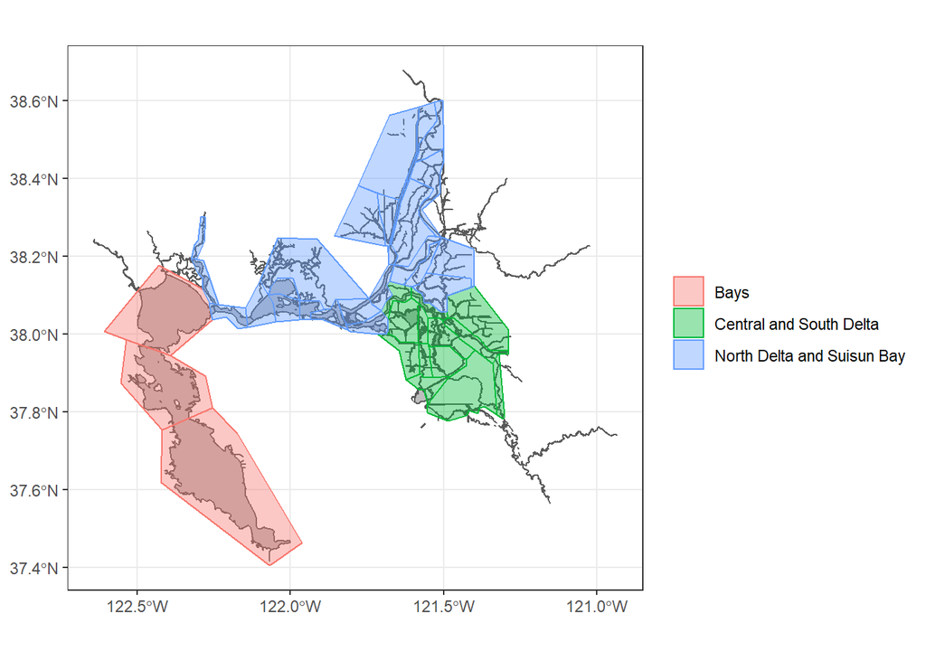

## Create spatial data frame, categorizing fish catch into regions

## Size cutoffs used for Delta Smelt

Larvae: (<20mm FL)

Juvenile: (20-58mm FL)

Adult: (>58mm FL)

### Brood year cutoff for the life stages

Larvae: brood year = calendar year

Juvenile: brood year starts in March 1st of current year to February 28th or 29th of the following year

Adult: brood year starts in June 1st of current year to May 31st of the following year

## Adult Delta Smelt

(>58 mm FL, cohort year set to June 1st - May 31st)

### Bays Region

| Cohort Year | 0.0% | 5.0% | 10.0% | 90.0% | 95.0% | 100.0% | Sample size |
| --- | --- | --- | --- | --- | --- | --- | --- |
| 1995 | March 05 1996 | March 05 1996 | March 05 1996 | March 05 1996 | March 05 1996 | March 05 1996 | 44 |
| 1996 | January 09 1997 | January 09 1997 | January 09 1997 | February 05 1997 | February 05 1997 | February 05 1997 | 3 |
| 1997 | September 03 1997 | September 03 1997 | March 02 1998 | March 04 1998 | March 04 1998 | March 04 1998 | 15 |
| 1998 | August 16 1998 | August 16 1998 | December 02 1998 | March 03 1999 | March 03 1999 | March 03 1999 | 14 |
| 1999 | March 08 2000 | March 08 2000 | March 08 2000 | March 08 2000 | March 08 2000 | March 08 2000 | 1 |
| 2016 | March 02 2017 | March 02 2017 | March 02 2017 | March 02 2017 | March 02 2017 | March 02 2017 | 1 |

### North Delta and Suisun Bay Region

| Cohort Year | 0.0% | 5.0% | 10.0% | 90.0% | 95.0% | 100.0% | Sample size |
| --- | --- | --- | --- | --- | --- | --- | --- |
| 1994 | June 01 1994 | June 20 1994 | November 23 1994 | April 22 1995 | May 06 1995 | May 31 1995 | 2004 |
| 1995 | June 01 1995 | September 25 1995 | October 25 1995 | May 10 1996 | May 16 1996 | May 31 1996 | 14254 |
| 1996 | June 03 1996 | June 03 1996 | June 08 1996 | May 19 1997 | May 27 1997 | May 31 1997 | 932 |
| 1997 | June 01 1997 | June 08 1997 | June 20 1997 | May 01 1998 | May 11 1998 | May 30 1998 | 1670 |
| 1998 | June 01 1998 | November 28 1998 | December 15 1998 | May 02 1999 | May 11 1999 | May 29 1999 | 4745 |
| 1999 | June 01 1999 | October 07 1999 | November 08 1999 | March 07 2000 | April 03 2000 | May 31 2000 | 5624 |
| 2000 | June 07 2000 | October 05 2000 | November 08 2000 | March 19 2001 | April 27 2001 | May 31 2001 | 1660 |
| 2001 | June 01 2001 | July 03 2001 | August 23 2001 | March 06 2002 | March 20 2002 | May 25 2002 | 1510 |
| 2002 | June 04 2002 | September 30 2002 | November 14 2002 | April 03 2003 | May 07 2003 | May 31 2003 | 1688 |
| 2003 | June 01 2003 | August 19 2003 | December 09 2003 | March 22 2004 | April 08 2004 | May 13 2004 | 1529 |
| 2004 | June 02 2004 | October 04 2004 | November 08 2004 | April 21 2005 | May 11 2005 | May 31 2005 | 1562 |
| 2005 | June 01 2005 | June 20 2005 | July 05 2005 | April 26 2006 | May 12 2006 | May 31 2006 | 1211 |
| 2006 | June 01 2006 | June 06 2006 | June 19 2006 | April 05 2007 | April 05 2007 | May 22 2007 | 1017 |
| 2007 | June 06 2007 | September 19 2007 | December 10 2007 | April 08 2008 | April 10 2008 | May 30 2008 | 395 |
| 2008 | June 06 2008 | September 03 2008 | December 16 2008 | March 18 2009 | April 15 2009 | May 27 2009 | 754 |
| 2009 | June 01 2009 | July 24 2009 | August 18 2009 | April 15 2010 | April 22 2010 | May 26 2010 | 700 |
| 2010 | June 07 2010 | July 19 2010 | August 16 2010 | April 06 2011 | April 11 2011 | May 25 2011 | 893 |
| 2011 | June 01 2011 | September 07 2011 | October 07 2011 | April 17 2012 | May 02 2012 | May 25 2012 | 2062 |
| 2012 | June 01 2012 | June 25 2012 | July 13 2012 | March 07 2013 | April 04 2013 | May 24 2013 | 836 |
| 2013 | June 07 2013 | July 22 2013 | November 13 2013 | April 08 2014 | April 10 2014 | May 08 2014 | 594 |
| 2014 | June 02 2014 | July 16 2014 | September 02 2014 | February 12 2015 | March 11 2015 | May 06 2015 | 161 |
| 2015 | July 01 2015 | August 03 2015 | September 01 2015 | April 04 2016 | April 04 2016 | May 23 2016 | 57 |
| 2016 | June 07 2016 | December 08 2016 | December 08 2016 | March 01 2017 | March 08 2017 | May 31 2017 | 402 |
| 2017 | June 07 2017 | July 20 2017 | August 09 2017 | February 14 2018 | March 07 2018 | March 22 2018 | 81 |
| 2018 | July 09 2018 | September 17 2018 | October 09 2018 | February 11 2019 | February 12 2019 | March 03 2019 | 42 |
| 2019 | November 29 2019 | November 29 2019 | December 04 2019 | March 05 2020 | March 16 2020 | March 16 2020 | 17 |

### Central and South Delta Region

| Cohort Year | 0.0% | 5.0% | 10.0% | 90.0% | 95.0% | 100.0% | Sample size |
| --- | --- | --- | --- | --- | --- | --- | --- |
| 1994 | December 08 1994 | December 08 1994 | February 08 1995 | April 03 1995 | May 01 1995 | May 01 1995 | 11 |
| 1995 | January 04 1996 | January 04 1996 | January 05 1996 | April 01 1996 | April 01 1996 | April 27 1996 | 40 |
| 1996 | January 15 1997 | January 15 1997 | March 03 1997 | April 16 1997 | April 16 1997 | April 16 1997 | 13 |
| 1997 | June 02 1997 | June 02 1997 | June 02 1997 | March 05 1998 | March 05 1998 | March 05 1998 | 9 |
| 1998 | March 01 1999 | March 01 1999 | March 01 1999 | May 10 1999 | May 28 1999 | May 28 1999 | 13 |
| 1999 | June 04 1999 | June 08 1999 | October 12 1999 | March 09 2000 | April 03 2000 | May 08 2000 | 40 |
| 2000 | June 12 2000 | June 12 2000 | September 13 2000 | May 07 2001 | May 07 2001 | May 07 2001 | 13 |
| 2001 | December 03 2001 | January 07 2002 | January 07 2002 | March 04 2002 | March 04 2002 | April 02 2002 | 74 |
| 2002 | June 16 2002 | December 26 2002 | January 23 2003 | April 16 2003 | April 16 2003 | April 16 2003 | 46 |
| 2003 | January 12 2004 | January 12 2004 | January 12 2004 | April 05 2004 | April 05 2004 | May 03 2004 | 278 |
| 2004 | January 03 2005 | January 03 2005 | January 24 2005 | February 18 2005 | March 11 2005 | March 11 2005 | 15 |
| 2005 | January 23 2006 | January 23 2006 | January 23 2006 | April 11 2006 | April 24 2006 | April 24 2006 | 10 |
| 2006 | January 08 2007 | January 08 2007 | January 08 2007 | January 08 2007 | January 08 2007 | January 08 2007 | 5 |
| 2007 | January 07 2008 | January 07 2008 | January 07 2008 | March 17 2008 | March 17 2008 | March 17 2008 | 6 |
| 2008 | January 12 2009 | January 12 2009 | January 12 2009 | April 13 2009 | April 13 2009 | April 13 2009 | 12 |
| 2009 | February 08 2010 | February 08 2010 | February 08 2010 | March 23 2010 | March 23 2010 | March 23 2010 | 4 |
| 2010 | January 10 2011 | January 10 2011 | January 10 2011 | April 04 2011 | April 04 2011 | April 04 2011 | 10 |
| 2011 | February 06 2012 | February 06 2012 | February 13 2012 | April 02 2012 | April 02 2012 | May 07 2012 | 38 |
| 2012 | August 09 2012 | January 07 2013 | January 07 2013 | April 29 2013 | April 29 2013 | April 29 2013 | 34 |
| 2013 | March 10 2014 | March 10 2014 | March 10 2014 | May 05 2014 | May 05 2014 | May 05 2014 | 3 |
| 2014 | December 15 2014 | December 15 2014 | January 05 2015 | February 09 2015 | February 09 2015 | February 09 2015 | 17 |
| 2015 | February 08 2016 | February 08 2016 | February 08 2016 | February 08 2016 | February 08 2016 | February 08 2016 | 1 |
| 2016 | December 15 2016 | December 15 2016 | December 27 2016 | March 01 2017 | March 07 2017 | March 16 2017 | 59 |
| 2018 | January 29 2019 | January 29 2019 | January 29 2019 | January 29 2019 | January 29 2019 | January 29 2019 | 1 |

Note that adult Delta Smelt can linger for more than a year (i.e, 1+ year old Delta Smelt). 2-year old Delta Smelt have even been observed in the past. This is why the first adult smelt can sometimes show up in June or July in the table. This phenomenon of 1+ year old Delta Smelt appear to be more common in the 1990s (or whenever smelt were more abundant). Example below:

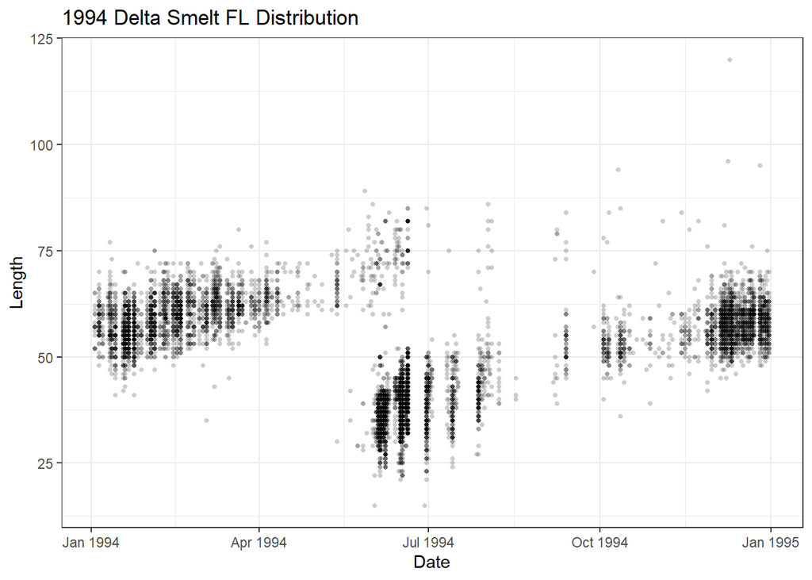

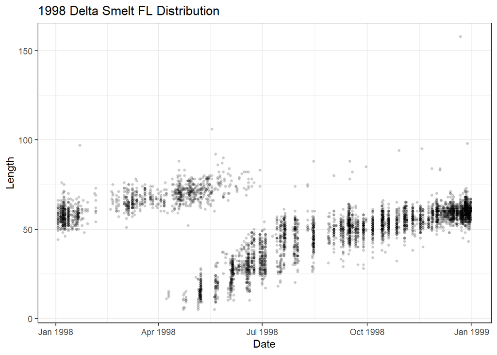

## Juvenile Delta Smelt

(20-58 mm FL, cohort year set to March 1st - February 28th/29th)

### Bays Region

| Cohort Year | 0.0% | 5.0% | 10.0% | 90.0% | 95.0% | 100.0% | Sample size |
| --- | --- | --- | --- | --- | --- | --- | --- |
| 1995 | July 11 1995 | July 11 1995 | July 21 1995 | September 07 1995 | September 07 1995 | October 12 1995 | 27 |
| 1996 | March 05 1996 | March 05 1996 | March 05 1996 | July 26 1996 | July 26 1996 | July 26 1996 | 10 |
| 1998 | March 04 1998 | July 13 1998 | July 21 1998 | August 16 1998 | September 03 1998 | December 08 1998 | 35 |
| 1999 | March 31 1999 | March 31 1999 | March 31 1999 | July 09 1999 | July 09 1999 | July 09 1999 | 3 |
| 2000 | November 02 2000 | November 02 2000 | November 02 2000 | December 26 2000 | December 26 2000 | December 26 2000 | 2 |
| 2002 | August 15 2002 | August 15 2002 | August 15 2002 | August 15 2002 | August 15 2002 | August 15 2002 | 2 |
| 2005 | January 10 2006 | January 10 2006 | January 10 2006 | January 10 2006 | January 10 2006 | January 10 2006 | 1 |
| 2006 | May 19 2006 | May 19 2006 | May 19 2006 | July 01 2006 | July 01 2006 | July 01 2006 | 15 |
| 2017 | August 23 2017 | August 23 2017 | August 23 2017 | September 12 2017 | September 12 2017 | September 12 2017 | 2 |

### North Delta and Suisun Bay Region

| Cohort Year | 0.0% | 5.0% | 10.0% | 90.0% | 95.0% | 100.0% | Sample size |
| --- | --- | --- | --- | --- | --- | --- | --- |
| 1994 | March 02 1994 | June 05 1994 | June 07 1994 | December 15 1994 | January 04 1995 | February 24 1995 | 8158 |
| 1995 | March 03 1995 | June 21 1995 | July 06 1995 | January 13 1996 | January 16 1996 | February 20 1996 | 8115 |
| 1996 | March 01 1996 | May 24 1996 | May 29 1996 | December 07 1996 | December 10 1996 | February 05 1997 | 5375 |
| 1997 | March 04 1997 | May 31 1997 | June 11 1997 | December 30 1997 | January 09 1998 | February 25 1998 | 2992 |
| 1998 | March 04 1998 | June 05 1998 | June 18 1998 | December 30 1998 | January 08 1999 | February 23 1999 | 3022 |
| 1999 | March 08 1999 | June 04 1999 | June 10 1999 | December 21 1999 | January 05 2000 | February 22 2000 | 4833 |
| 2000 | March 07 2000 | June 01 2000 | June 13 2000 | December 18 2000 | January 30 2001 | February 26 2001 | 5344 |
| 2001 | March 02 2001 | May 05 2001 | May 05 2001 | October 10 2001 | October 10 2001 | February 15 2002 | 2391 |
| 2002 | March 06 2002 | May 15 2002 | June 11 2002 | October 16 2002 | November 06 2002 | January 24 2003 | 888 |
| 2003 | May 06 2003 | June 05 2003 | June 17 2003 | January 27 2004 | January 27 2004 | February 24 2004 | 1284 |
| 2004 | March 09 2004 | May 25 2004 | May 26 2004 | October 07 2004 | November 24 2004 | February 24 2005 | 772 |
| 2005 | March 02 2005 | May 13 2005 | May 26 2005 | October 03 2005 | December 14 2005 | February 22 2006 | 793 |
| 2006 | May 05 2006 | May 20 2006 | June 03 2006 | January 10 2007 | January 22 2007 | February 22 2007 | 1081 |
| 2007 | March 06 2007 | May 10 2007 | June 12 2007 | August 21 2007 | December 12 2007 | February 04 2008 | 184 |
| 2008 | April 29 2008 | June 03 2008 | June 09 2008 | January 14 2009 | January 14 2009 | February 13 2009 | 443 |
| 2009 | March 18 2009 | May 06 2009 | May 20 2009 | August 26 2009 | October 26 2009 | January 14 2010 | 429 |
| 2010 | March 10 2010 | May 10 2010 | May 10 2010 | August 11 2010 | October 04 2010 | February 10 2011 | 763 |
| 2011 | April 01 2011 | May 25 2011 | June 07 2011 | December 07 2011 | January 19 2012 | February 22 2012 | 2222 |
| 2012 | March 05 2012 | May 21 2012 | May 23 2012 | July 26 2012 | September 04 2012 | February 06 2013 | 711 |
| 2013 | April 08 2013 | May 06 2013 | May 07 2013 | September 03 2013 | September 18 2013 | February 12 2014 | 1074 |
| 2014 | March 12 2014 | April 28 2014 | May 12 2014 | August 14 2014 | October 09 2014 | January 15 2015 | 302 |
| 2015 | April 16 2015 | April 27 2015 | May 08 2015 | September 01 2015 | September 01 2015 | December 01 2015 | 162 |
| 2016 | March 09 2016 | April 13 2016 | April 27 2016 | December 28 2016 | December 28 2016 | February 08 2017 | 128 |
| 2017 | March 08 2017 | May 08 2017 | May 24 2017 | September 18 2017 | October 10 2017 | January 10 2018 | 513 |
| 2018 | May 02 2018 | July 05 2018 | July 17 2018 | November 07 2018 | December 28 2018 | February 25 2019 | 160 |
| 2019 | April 29 2019 | June 18 2019 | July 03 2019 | September 17 2019 | October 15 2019 | January 15 2020 | 146 |
| 2020 | May 05 2020 | May 11 2020 | May 19 2020 | September 23 2020 | January 06 2021 | January 26 2021 | 35 |
| 2021 | May 06 2021 | May 06 2021 | May 06 2021 | May 06 2021 | May 06 2021 | May 06 2021 | 1 |

### Central and South Delta Region

| Cohort Year | 0.0% | 5.0% | 10.0% | 90.0% | 95.0% | 100.0% | Sample size |
| --- | --- | --- | --- | --- | --- | --- | --- |
| 1994 | June 02 1994 | June 02 1994 | June 06 1994 | June 16 1994 | July 27 1994 | January 10 1995 | 20 |
| 1995 | July 03 1995 | July 03 1995 | July 03 1995 | August 18 1995 | August 18 1995 | August 18 1995 | 3 |
| 1996 | May 09 1996 | May 09 1996 | May 09 1996 | July 22 1996 | July 22 1996 | November 04 1996 | 26 |
| 1997 | April 28 1997 | April 28 1997 | May 13 1997 | June 27 1997 | July 08 1997 | January 12 1998 | 35 |
| 1998 | May 04 1998 | May 04 1998 | May 04 1998 | July 10 1998 | July 10 1998 | July 10 1998 | 4 |
| 1999 | April 27 1999 | May 10 1999 | May 24 1999 | June 14 1999 | June 24 1999 | November 08 1999 | 219 |
| 2000 | April 24 2000 | May 07 2000 | May 15 2000 | June 26 2000 | June 26 2000 | July 21 2000 | 90 |
| 2001 | April 30 2001 | May 15 2001 | May 29 2001 | October 04 2001 | January 07 2002 | February 04 2002 | 104 |
| 2002 | May 13 2002 | May 13 2002 | May 13 2002 | June 24 2002 | June 24 2002 | June 29 2002 | 99 |
| 2003 | May 06 2003 | May 19 2003 | May 19 2003 | January 26 2004 | February 11 2004 | February 23 2004 | 41 |
| 2004 | May 10 2004 | May 10 2004 | May 10 2004 | June 07 2004 | June 09 2004 | July 19 2004 | 49 |
| 2005 | May 09 2005 | May 09 2005 | May 09 2005 | January 17 2006 | January 17 2006 | January 17 2006 | 6 |
| 2006 | January 08 2007 | January 08 2007 | January 08 2007 | January 08 2007 | January 08 2007 | January 08 2007 | 1 |
| 2007 | June 04 2007 | June 04 2007 | June 04 2007 | July 03 2007 | July 03 2007 | July 03 2007 | 2 |
| 2008 | May 12 2008 | May 12 2008 | May 12 2008 | June 16 2008 | June 30 2008 | June 30 2008 | 15 |
| 2009 | June 01 2009 | June 01 2009 | June 01 2009 | June 01 2009 | June 01 2009 | June 01 2009 | 1 |
| 2010 | June 14 2010 | June 14 2010 | June 14 2010 | July 29 2010 | July 29 2010 | July 29 2010 | 2 |
| 2011 | June 06 2011 | June 06 2011 | June 06 2011 | June 06 2011 | June 06 2011 | June 06 2011 | 1 |
| 2012 | May 07 2012 | May 07 2012 | May 21 2012 | June 25 2012 | July 09 2012 | August 06 2012 | 25 |
| 2013 | April 22 2013 | May 06 2013 | May 06 2013 | June 10 2013 | June 24 2013 | June 24 2013 | 42 |
| 2014 | May 12 2014 | May 12 2014 | May 12 2014 | May 12 2014 | May 12 2014 | May 12 2014 | 1 |
| 2015 | April 28 2015 | April 28 2015 | April 28 2015 | June 08 2015 | June 08 2015 | June 08 2015 | 2 |
| 2016 | May 11 2016 | May 11 2016 | May 11 2016 | December 22 2016 | December 22 2016 | December 22 2016 | 4 |
| 2017 | August 09 2017 | August 09 2017 | August 09 2017 | August 09 2017 | August 09 2017 | August 09 2017 | 1 |

## Larval Delta Smelt

(<20 mm FL, cohort year set to just calendar year)

### Bays Region

| Cohort Year | 0.0% | 5.0% | 10.0% | 90.0% | 95.0% | 100.0% | Sample size |
| --- | --- | --- | --- | --- | --- | --- | --- |
| 1995 | May 12 1995 | May 12 1995 | May 12 1995 | May 26 1995 | May 26 1995 | May 26 1995 | 228 |
| 1996 | April 17 1996 | April 17 1996 | April 17 1996 | April 17 1996 | April 17 1996 | April 17 1996 | 2007 |
| 2006 | April 22 2006 | April 22 2006 | April 22 2006 | May 19 2006 | May 19 2006 | June 17 2006 | 587 |
| 2011 | April 25 2011 | April 25 2011 | April 25 2011 | May 10 2011 | May 10 2011 | May 10 2011 | 666 |
| 2019 | April 24 2019 | April 24 2019 | April 24 2019 | April 24 2019 | April 24 2019 | April 24 2019 | 13 |

### North Delta and Suisun Bay Region

| Cohort Year | 0.0% | 5.0% | 10.0% | 90.0% | 95.0% | 100.0% | Sample size |
| --- | --- | --- | --- | --- | --- | --- | --- |
| 1995 | April 27 1995 | May 10 1995 | May 12 1995 | July 19 1995 | July 20 1995 | August 07 1995 | 228 |
| 1996 | April 11 1996 | April 27 1996 | April 30 1996 | June 14 1996 | June 26 1996 | July 25 1996 | 2007 |
| 1997 | April 15 1997 | May 13 1997 | May 14 1997 | June 11 1997 | June 11 1997 | July 24 1997 | 1148 |
| 1998 | April 08 1998 | April 24 1998 | May 06 1998 | June 18 1998 | June 20 1998 | July 30 1998 | 229 |
| 1999 | April 13 1999 | April 16 1999 | April 30 1999 | July 08 1999 | July 08 1999 | August 03 1999 | 1378 |
| 2000 | March 21 2000 | April 07 2000 | May 03 2000 | June 14 2000 | June 15 2000 | July 11 2000 | 2007 |
| 2001 | March 21 2001 | April 07 2001 | April 07 2001 | May 05 2001 | May 05 2001 | June 30 2001 | 4193 |
| 2002 | April 16 2002 | April 17 2002 | April 17 2002 | June 14 2002 | June 14 2002 | June 29 2002 | 300 |
| 2003 | March 25 2003 | March 26 2003 | April 09 2003 | June 18 2003 | July 01 2003 | July 03 2003 | 363 |
| 2004 | April 01 2004 | April 14 2004 | April 14 2004 | May 27 2004 | June 10 2004 | June 22 2004 | 309 |
| 2005 | March 16 2005 | April 27 2005 | April 28 2005 | June 08 2005 | June 09 2005 | July 08 2005 | 384 |
| 2006 | April 21 2006 | May 18 2006 | May 19 2006 | June 17 2006 | June 29 2006 | July 18 2006 | 587 |
| 2007 | March 14 2007 | March 16 2007 | March 16 2007 | June 20 2007 | June 20 2007 | June 20 2007 | 31 |
| 2008 | April 14 2008 | April 14 2008 | April 14 2008 | June 09 2008 | June 09 2008 | June 12 2008 | 62 |
| 2009 | April 06 2009 | April 08 2009 | April 22 2009 | June 15 2009 | June 15 2009 | July 01 2009 | 168 |
| 2010 | March 17 2010 | April 12 2010 | April 26 2010 | June 25 2010 | July 08 2010 | July 08 2010 | 430 |
| 2011 | March 15 2011 | April 26 2011 | April 26 2011 | June 21 2011 | July 05 2011 | July 07 2011 | 666 |
| 2012 | March 19 2012 | March 19 2012 | March 20 2012 | June 05 2012 | June 06 2012 | July 12 2012 | 948 |
| 2013 | March 18 2013 | March 18 2013 | March 19 2013 | May 20 2013 | May 21 2013 | July 03 2013 | 655 |
| 2014 | March 03 2014 | March 04 2014 | March 18 2014 | May 12 2014 | May 13 2014 | May 27 2014 | 132 |
| 2015 | March 03 2015 | March 16 2015 | March 25 2015 | May 13 2015 | May 13 2015 | June 23 2015 | 42 |
| 2016 | March 15 2016 | March 15 2016 | March 28 2016 | May 12 2016 | May 25 2016 | June 22 2016 | 67 |
| 2017 | March 13 2017 | March 15 2017 | March 15 2017 | May 24 2017 | June 05 2017 | July 05 2017 | 116 |
| 2018 | March 12 2018 | March 12 2018 | March 12 2018 | March 29 2018 | April 11 2018 | June 12 2018 | 33 |
| 2019 | March 11 2019 | March 11 2019 | March 12 2019 | May 21 2019 | June 05 2019 | June 05 2019 | 13 |
| 2020 | March 17 2020 | March 17 2020 | March 17 2020 | May 11 2020 | May 19 2020 | May 20 2020 | 38 |

### Central and South Delta Region

| Cohort Year | 0.0% | 5.0% | 10.0% | 90.0% | 95.0% | 100.0% | Sample size |
| --- | --- | --- | --- | --- | --- | --- | --- |
| 1994 | June 02 1994 | June 02 1994 | June 02 1994 | June 29 1994 | June 29 1994 | June 29 1994 | 2 |
| 1995 | July 03 1995 | July 03 1995 | July 03 1995 | July 03 1995 | July 03 1995 | July 03 1995 | 228 |
| 1996 | April 10 1996 | April 10 1996 | April 11 1996 | June 08 1996 | June 09 1996 | July 08 1996 | 2007 |
| 1997 | March 31 1997 | April 14 1997 | April 14 1997 | May 27 1997 | May 27 1997 | July 08 1997 | 1148 |
| 1998 | June 01 1998 | June 01 1998 | June 01 1998 | June 01 1998 | June 01 1998 | June 01 1998 | 229 |
| 1999 | April 12 1999 | April 12 1999 | April 28 1999 | June 14 1999 | June 14 1999 | July 06 1999 | 1378 |
| 2000 | March 20 2000 | April 17 2000 | April 18 2000 | June 13 2000 | June 13 2000 | July 10 2000 | 2007 |
| 2001 | April 02 2001 | April 16 2001 | April 30 2001 | May 30 2001 | June 11 2001 | June 13 2001 | 4193 |
| 2002 | April 02 2002 | April 02 2002 | April 02 2002 | May 29 2002 | June 11 2002 | June 24 2002 | 300 |
| 2003 | March 24 2003 | April 07 2003 | April 07 2003 | June 17 2003 | June 30 2003 | July 01 2003 | 363 |
| 2004 | March 29 2004 | April 13 2004 | April 26 2004 | May 24 2004 | June 07 2004 | June 09 2004 | 309 |
| 2005 | March 15 2005 | March 28 2005 | March 28 2005 | June 06 2005 | June 07 2005 | July 05 2005 | 384 |
| 2006 | May 16 2006 | May 16 2006 | May 16 2006 | May 16 2006 | May 16 2006 | May 16 2006 | 587 |
| 2007 | May 07 2007 | May 07 2007 | May 07 2007 | May 07 2007 | May 07 2007 | May 07 2007 | 31 |
| 2008 | April 14 2008 | April 14 2008 | April 15 2008 | May 28 2008 | June 09 2008 | June 09 2008 | 62 |
| 2009 | April 06 2009 | April 06 2009 | April 06 2009 | May 20 2009 | June 16 2009 | June 16 2009 | 168 |
| 2010 | April 13 2010 | April 13 2010 | April 13 2010 | June 22 2010 | June 22 2010 | June 22 2010 | 430 |
| 2011 | May 23 2011 | May 23 2011 | May 23 2011 | June 06 2011 | June 06 2011 | June 06 2011 | 666 |
| 2012 | March 19 2012 | March 19 2012 | March 19 2012 | June 05 2012 | June 18 2012 | June 18 2012 | 948 |
| 2013 | March 18 2013 | March 18 2013 | March 19 2013 | May 20 2013 | June 03 2013 | June 17 2013 | 655 |
| 2014 | March 17 2014 | March 17 2014 | March 17 2014 | May 12 2014 | May 27 2014 | May 27 2014 | 132 |
| 2015 | March 24 2015 | March 24 2015 | March 24 2015 | May 11 2015 | May 11 2015 | May 11 2015 | 42 |
| 2016 | March 14 2016 | March 14 2016 | March 14 2016 | June 06 2016 | June 06 2016 | June 06 2016 | 67 |
| 2018 | March 19 2018 | March 19 2018 | March 19 2018 | March 19 2018 | March 19 2018 | March 19 2018 | 33 |